# Hypothesis_Testing

## Visualization:

```r
par(mfrow = c(1, 2))

plot(sort(pop_auto.price), sort(pop_auto.norm), main = 'Plot of Price vs. normalized',
     xlab = 'Sample Quantiles', ylab = 'Theoritical Quantiles')
abline(a = 0.0, b = 1.0, lty = 2, col = 'red')

plot(sort(pop_auto.log.price), sort(pop_auto.norm), main = 'Plot of log price vs. normalized',
     xlab = 'Sample Quantiles', ylab = 'Theoritical Quantiles')
abline(a = 0.0, b = 1.0, lty = 2, col = 'red')
```

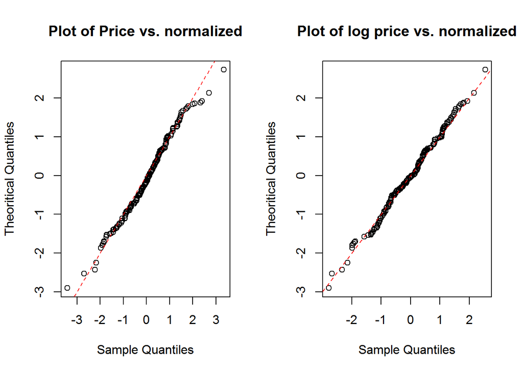

[figure not shown]

```r
par(mfrow = c(1, 1))
```

Lets draw a CDF plot for log price vs standard normalized data.

```r
# Have to standardize the x-values
x_seq = seq(-3,3,len=nrow(read.auto))
y_cdf1 = sapply(x_seq, function(x){
        sum(read.auto$scaled.log.price<x)/length(read.auto$scaled.log.price)
})
y_cdf2 = sapply(x_seq, function(x){
        sum(pop_auto.norm<x)/length(pop_auto.norm)
})

## Find the max deviation
k_s_stat = max(abs(y_cdf1 - y_cdf2))
k_s_stat
```

```
## [1] 0.09189189
```

```r
# where does it occur?
k_index = which.max(abs(y_cdf1-y_cdf2))
k_s_x = x_seq[k_index]
plot(x_seq,y_cdf1, col='blue', pch=16, main ='CDFs of standardized samples',
     xlab = 'Value', ylab = 'Cumulative density')
points(x_seq,y_cdf2,col='red', pch=16)
lines(c(k_s_x,k_s_x), c(y_cdf1[k_index],y_cdf2[k_index]),
      col='black', lwd=8)
```

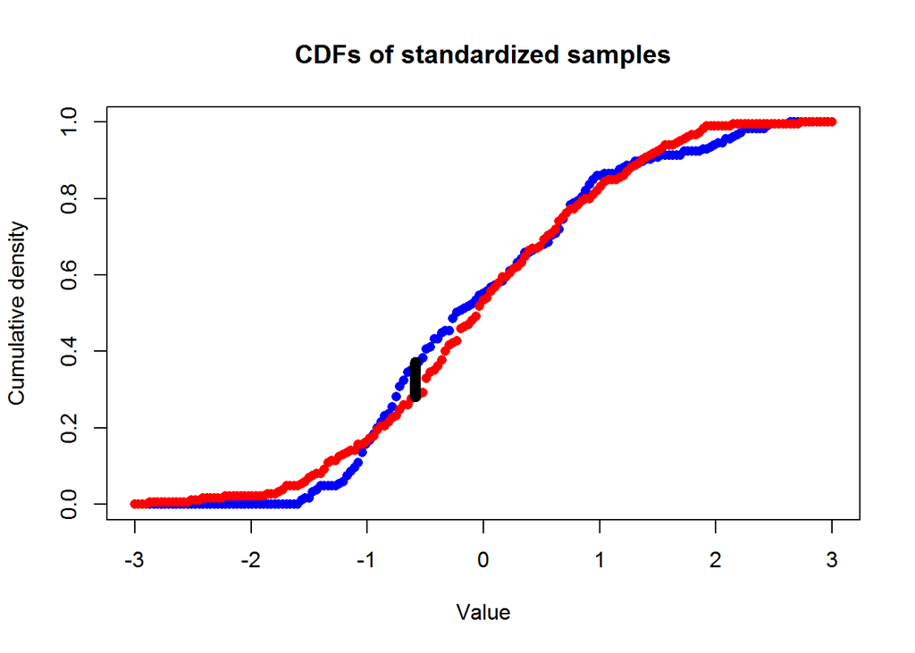

[figure not shown]

Lets do our second question:

**2**. Test significance of price (log price) stratified by a) fuel type, b) aspiration, and c) rear vs. front wheel drive. Use both graphical methods and the formal test.

```r
plot.t <- function(a, b, cols = c('pop_A', 'pop_B'), nbins = 20){
        maxs = max(c(max(a), max(b)))
        mins = min(c(min(a), min(b)))
        breaks = seq(maxs, mins, length.out = (nbins + 1))
        par(mfrow = c(2, 1))
        hist(a, breaks = breaks, main = paste('Histogram of', cols[1]), xlab = cols[1])
        abline(v = mean(a), lwd = 4, col = 'red')
        hist(b, breaks = breaks, main = paste('Histogram of', cols[2]), xlab = cols[2])
        abline(v = mean(b), lwd = 4, col = 'red')
        par(mfrow = c(1, 1))
}
```

For this analysis, i am stratifying the data by 10 records for each group.

**2(a). Lets start the analysis for log price by fuel type.**

**Null Hypothesis:** Significance of log price by fuel type. There is no price difference with the fuel type.

```r
n = 10

auto.fuel.type = read.auto %>% group_by(fuel.type ) %>%
        sample_n(n, replace = FALSE)

auto.fuel.type.bydiesel <-  auto.fuel.type[auto.fuel.type$fuel.type=="diesel",]
auto.fuel.type.bygas <-  auto.fuel.type[auto.fuel.type$fuel.type=="gas",]

pop_A = auto.fuel.type.bydiesel$scaled.log.price
pop_B = auto.fuel.type.bygas$scaled.log.price

plot.t(pop_A, pop_B, cols = c("Log price by Diesel", "Log price by Gas"))
```

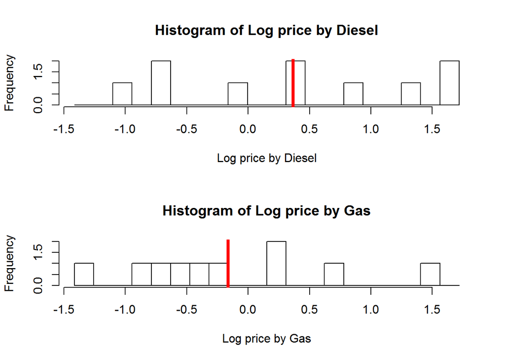

[figure not shown]

```r
ks.test(pop_A, pop_B, alternative = "two.sided")
```

[output not shown]

**Conclusion:** Based on the above results, we failed to reject, hence we **ACCEPT** the null hypothesis.

**2(b). Lets start the analysis for log price by aspiration.**

**Null Hypothesis:** Significance of log price by aspiration. There is no price difference with the aspiration.

```r
auto.aspiration.type = read.auto %>% group_by(aspiration) %>%
        sample_n(n, replace = FALSE)

auto.aspiration.type.std <-  auto.aspiration.type[auto.aspiration.type$aspiration=="std",]
auto.aspiration.type.turbo <-  auto.aspiration.type[auto.aspiration.type$aspiration=="turbo",]


pop_A = auto.aspiration.type.std$scaled.log.price
pop_B = auto.aspiration.type.turbo$scaled.log.price

plot.t(pop_A, pop_B, cols = c("Log price by std", "Log price by turbo"))
```

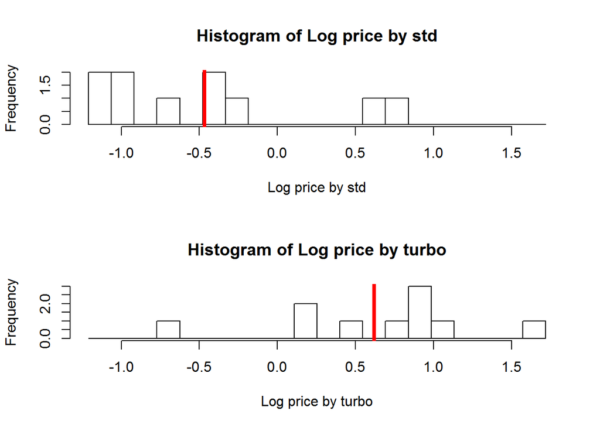

[figure not shown]

```r
ks.test(pop_A, pop_B, alternative = "two.sided")
```

[output not shown]

**2(C). Lets start the analysis for log price by drive wheels**

**Null Hypothesis:** Significance of log price by drive wheels There is no price difference with the drive wheels.

```r
auto.drive.wheels = read.auto %>% group_by(drive.wheels) %>%
        sample_n(n, replace = FALSE)

auto.drive.wheels.rwd <-  auto.drive.wheels[auto.drive.wheels$drive.wheels=="rwd",]
auto.drive.wheels.fwd <-  auto.drive.wheels[auto.drive.wheels$drive.wheels=="fwd",]


pop_A = auto.drive.wheels.rwd$scaled.log.price
pop_B = auto.drive.wheels.fwd$scaled.log.price
#plot.t(pop_A, pop_B)

ks.test(pop_A, pop_B, alternative = "two.sided")
```

[output not shown]

[figure not shown]

```r
plot.t(pop_A, pop_B, cols = c("Log price by rwd", "Log price by fwd"))
```

```r
ks.test(pop_A, pop_B, alternative = "two.sided")
```

[figure not shown]

```r
plot.t(pop_A, pop_B)
```

```r
ks.test(pop_A, pop_B, alternative = "two.sided")
```

[output not shown]

**Conclusion:** Based on the above results, we **REJECT** the null hypothesis.

3. Apply ANOVA to the auto price data to compare the price (or log price if closer to a Normal distribution) of autos stratified by number of doors, and body style - two sets of tests.

**Null Hypothesis:** Significance of log price by Num of doors and body style. There is no price variances with the influence of Num of doors and body style.

```r
auto.anova.sample = read.auto %>% group_by(num.of.doors, body.style) %>%
        sample_n(n, replace = TRUE)

boxplot(auto.anova.sample$scaled.log.price ~ auto.anova.sample$num.of.doors+
                auto.anova.sample$body.style)
```

[figure not shown]

```r
df_aov = aov(scaled.log.price ~ num.of.doors + body.style, data = auto.anova.sample)
summary(df_aov)
```

[output not shown]

[figure not shown]

[figure not shown]

[figure not shown]

[figure not shown]

[figure not shown]

```r
plot(tukey_anova)
```